# Assignment 5

Matthew Mayor

9/29/2019

To start on this assignment, I loaded all the necessary libraries: plyr, dplyr, tidyr, and ggplot2.

```r
library(plyr)
library(dplyr)
```

```r
library(tidyr)
library(ggplot2)
```

I then loaded the CSV file from GitHub where I uploaded it.

```r
flights <- read.csv("https://raw.githubusercontent.com/MJJMayor/DATA607/master/airlines.csv")
flights
```

```
##         X     X.1 Los.Angeles Phoenix San.Diego San.Francisco Seattle
## 1  ALASKA on time         497     221       212           503    1841
## 2         delayed          62      12        20           102     305
## 3                          NA      NA        NA            NA      NA
## 4 AM WEST on time         694    4840       383           320     201
## 5         delayed         117     415        65           129      61
```

As you can see, it needs some tidying. First was to get rid of the empty row.

```r
flights <- slice(flights, c(1,2,4,5))
flights
```

```
##         X     X.1 Los.Angeles Phoenix San.Diego San.Francisco Seattle
## 1  ALASKA on time         497     221       212           503    1841
## 2         delayed          62      12        20           102     305
## 3 AM WEST on time         694    4840       383           320     201
## 4         delayed         117     415        65           129      61
```

Next, I needed to fill in the blank values in the first column with the appropriate airline.

```r
flights$X <- c("ALASKA","ALASKA","AM WEST", "AM WEST")
flights
```

```
##         X     X.1 Los.Angeles Phoenix San.Diego San.Francisco Seattle
## 1  ALASKA on time         497     221       212           503    1841
## 2  ALASKA delayed          62      12        20           102     305
## 3 AM WEST on time         694    4840       383           320     201
## 4 AM WEST delayed         117     415        65           129      61
```

Next was to fix the problem of some of the columns being values.

```r
flights <- gather(flights, "Dest", "Freq", 3:7)
flights
```

```
##          X     X.1          Dest Freq
## 1   ALASKA on time   Los.Angeles  497
## 2   ALASKA delayed   Los.Angeles   62
## 3  AM WEST on time   Los.Angeles  694
## 4  AM WEST delayed   Los.Angeles  117
## 5   ALASKA on time       Phoenix  221
## 6   ALASKA delayed       Phoenix   12
## 7  AM WEST on time       Phoenix 4840
## 8  AM WEST delayed       Phoenix  415
## 9   ALASKA on time     San.Diego  212
## 10  ALASKA delayed     San.Diego   20
## 11 AM WEST on time     San.Diego  383
## 12 AM WEST delayed     San.Diego   65
## 13  ALASKA on time San.Francisco  503
## 14  ALASKA delayed San.Francisco  102
## 15 AM WEST on time San.Francisco  320
## 16 AM WEST delayed San.Francisco  129
## 17  ALASKA on time       Seattle 1841
## 18  ALASKA delayed       Seattle  305
## 19 AM WEST on time       Seattle  201
## 20 AM WEST delayed       Seattle   61
```

Next, was to rename the first two columns that were previously given default names.

```r
flights <- rename(flights, Airline = X, Arrival = X.1)
flights
```

```
##    Airline Arrival          Dest Freq
## 1   ALASKA on time   Los.Angeles  497
## 2   ALASKA delayed   Los.Angeles   62
## 3  AM WEST on time   Los.Angeles  694
## 4  AM WEST delayed   Los.Angeles  117
## 5   ALASKA on time       Phoenix  221
## 6   ALASKA delayed       Phoenix   12
## 7  AM WEST on time       Phoenix 4840
## 8  AM WEST delayed       Phoenix  415
## 9   ALASKA on time     San.Diego  212
## 10  ALASKA delayed     San.Diego   20
## 11 AM WEST on time     San.Diego  383
## 12 AM WEST delayed     San.Diego   65
## 13  ALASKA on time San.Francisco  503
## 14  ALASKA delayed San.Francisco  102
## 15 AM WEST on time San.Francisco  320
## 16 AM WEST delayed San.Francisco  129
## 17  ALASKA on time       Seattle 1841
## 18  ALASKA delayed       Seattle  305
## 19 AM WEST on time       Seattle  201
## 20 AM WEST delayed       Seattle   61
```

Now, according to tidy rules, I had to reorder the columns so that the fixed values came before the observed values. In doing so I put the destination before the arrival status.

```r
flights <- select(flights, Airline, Dest, Arrival, Freq)
flights
```

```
##    Airline          Dest Arrival Freq
## 1   ALASKA   Los.Angeles on time  497
## 2   ALASKA   Los.Angeles delayed   62
## 3  AM WEST   Los.Angeles on time  694
## 4  AM WEST   Los.Angeles delayed  117
## 5   ALASKA       Phoenix on time  221
## 6   ALASKA       Phoenix delayed   12
## 7  AM WEST       Phoenix on time 4840
## 8  AM WEST       Phoenix delayed  415
## 9   ALASKA     San.Diego on time  212
## 10  ALASKA     San.Diego delayed   20
## 11 AM WEST     San.Diego on time  383
## 12 AM WEST     San.Diego delayed   65
## 13  ALASKA San.Francisco on time  503
## 14  ALASKA San.Francisco delayed  102
## 15 AM WEST San.Francisco on time  320
## 16 AM WEST San.Francisco delayed  129
## 17  ALASKA       Seattle on time 1841
## 18  ALASKA       Seattle delayed  305
## 19 AM WEST       Seattle on time  201
## 20 AM WEST       Seattle delayed   61
```

The table is now in tidy condition. Next is to do some analysis.

I start by using ddply to create a new column that stores the proportion of flights with a certain arrival status grouped by airline and destination.

```r
flights <- ddply(flights, .(Airline,Dest), transform, prop = Freq/sum(Freq))
flights
```

```
##    Airline          Dest Arrival Freq       prop
## 1   ALASKA   Los.Angeles on time  497 0.88908766
## 2   ALASKA   Los.Angeles delayed   62 0.11091234
## 3   ALASKA       Phoenix on time  221 0.94849785
## 4   ALASKA       Phoenix delayed   12 0.05150215
## 5   ALASKA     San.Diego on time  212 0.91379310
## 6   ALASKA     San.Diego delayed   20 0.08620690
## 7   ALASKA San.Francisco on time  503 0.83140496
## 8   ALASKA San.Francisco delayed  102 0.16859504
## 9   ALASKA       Seattle on time 1841 0.85787512
## 10  ALASKA       Seattle delayed  305 0.14212488
## 11 AM WEST   Los.Angeles on time  694 0.85573366
## 12 AM WEST   Los.Angeles delayed  117 0.14426634
## 13 AM WEST       Phoenix on time 4840 0.92102759
## 14 AM WEST       Phoenix delayed  415 0.07897241
## 15 AM WEST     San.Diego on time  383 0.85491071
## 16 AM WEST     San.Diego delayed   65 0.14508929
## 17 AM WEST San.Francisco on time  320 0.71269488
## 18 AM WEST San.Francisco delayed  129 0.28730512
## 19 AM WEST       Seattle on time  201 0.76717557
## 20 AM WEST       Seattle delayed   61 0.23282443
```

Next, I used arrange() to revert the table to the same sorting it had previously.

```r
flights <- arrange(flights, Dest)
flights
```

```
##    Airline          Dest Arrival Freq       prop
## 1   ALASKA   Los.Angeles on time  497 0.88908766
## 2   ALASKA   Los.Angeles delayed   62 0.11091234
## 3  AM WEST   Los.Angeles on time  694 0.85573366
## 4  AM WEST   Los.Angeles delayed  117 0.14426634
## 5   ALASKA       Phoenix on time  221 0.94849785
## 6   ALASKA       Phoenix delayed   12 0.05150215
## 7  AM WEST       Phoenix on time 4840 0.92102759
## 8  AM WEST       Phoenix delayed  415 0.07897241
## 9   ALASKA     San.Diego on time  212 0.91379310
## 10  ALASKA     San.Diego delayed   20 0.08620690
## 11 AM WEST     San.Diego on time  383 0.85491071
## 12 AM WEST     San.Diego delayed   65 0.14508929
## 13  ALASKA San.Francisco on time  503 0.83140496
## 14  ALASKA San.Francisco delayed  102 0.16859504
## 15 AM WEST San.Francisco on time  320 0.71269488
## 16 AM WEST San.Francisco delayed  129 0.28730512
## 17  ALASKA       Seattle on time 1841 0.85787512
## 18  ALASKA       Seattle delayed  305 0.14212488
## 19 AM WEST       Seattle on time  201 0.76717557
## 20 AM WEST       Seattle delayed   61 0.23282443
```

Last, I plotted the proportion of on time arrivals at each airport between each airline in a bar plot.

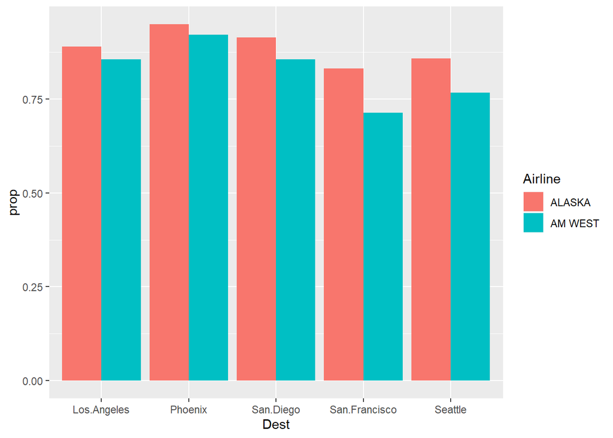

```r
ggplot(data=flights, aes(x=Dest, y=prop, fill=Airline)) + geom_bar(stat="identity", position=position_dodge())
```

From this plot you can see that at every airport, ALASKA had a higher proportion of on time arrivals. The difference is the starkest at San Francisco and Seattle.